# Assignment 2

## Andrew Singh

### 11/20/2024

#### Q1

#### Read in the city_sales20.xlsx. Download city_sales20.xlsxdata so that the data does note contain any additional text or notes, only the data on offices and sales

```python
import pandas as pd
import numpy as np
import seaborn as sns
%pip install altair
import altair as alt
%pip install plotnine
from plotnine import *
```

```python
city_sales = pd.read_excel("city_sales20.xlsx")
```

```python
city_sales
```

|  | Sales figures for metropolitan locations | Unnamed: 1 | Unnamed: 2 | Unnamed: 3 | Unnamed: 4 | Unnamed: 5 | Unnamed: 6 | Unnamed: 7 | Unnamed: 8 |
| --- | --- | --- | --- | --- | --- | --- | --- | --- | --- |
| 0 | Figures are in 1000s of USD | NaN | NaN | NaN | NaN | NaN | NaN | NaN | NaN |
| 1 | NaN | NaN | NaN | NaN | NaN | NaN | NaN | NaN | NaN |
| 2 | office | 2013.0 | 2014.0 | 2015.0 | 2016.0 | 2017.0 | 2018.0 | 2019.0 | 2020.0 |
| 3 | NY | 45.0 | 31.0 | 34.0 | 56.0 | 67.0 | 45.0 | 67.0 | 45.0 |
| 4 | BOS | 34.0 | 23.0 | 24.0 | 26.0 | 25.0 | 34.0 | 26.0 | 22.0 |
| 5 | MIA | 45.0 | 81.0 | 43.0 | 44.0 | 41.0 | 45.0 | 51.0 | 41.0 |
| 6 | DC | 12.0 | 13.0 | 15.0 | 11.0 | 11.0 | 18.0 | 19.0 | 20.0 |
| 7 | SEA | 52.0 | 48.0 | 47.0 | 41.0 | 41.0 | 42.0 | 44.0 | 42.0 |
| 8 | PHI | 43.0 | 39.0 | 38.0 | 38.0 | 33.0 | 35.0 | 41.0 | 40.0 |
| 9 | CHI | 36.0 | 35.0 | 36.0 | 39.0 | 38.0 | 33.0 | 29.0 | 27.0 |
| 10 | NaN | NaN | NaN | NaN | NaN | NaN | NaN | NaN | NaN |
| 11 | NaN | NaN | NaN | NaN | NaN | NaN | NaN | NaN | NaN |
| 12 | Main departments included in collection: finan... | NaN | NaN | NaN | NaN | NaN | NaN | NaN | NaN |
| 13 | Please refer to HP507 for additional details a... | NaN | NaN | NaN | NaN | NaN | NaN | NaN | NaN |

```python
city_sales = pd.read_excel("city_sales20.xlsx",
                           skiprows = 3,
                           skipfooter =4)
```

```python
city_sales
```

|  | office | 2013 | 2014 | 2015 | 2016 | 2017 | 2018 | 2019 | 2020 |
| --- | --- | --- | --- | --- | --- | --- | --- | --- | --- |
| 0 | NY | 45 | 31 | 34 | 56 | 67 | 45 | 67 | 45 |
| 1 | BOS | 34 | 23 | 24 | 26 | 25 | 34 | 26 | 22 |
| 2 | MIA | 45 | 81 | 43 | 44 | 41 | 45 | 51 | 41 |
| 3 | DC | 12 | 13 | 15 | 11 | 11 | 18 | 19 | 20 |
| 4 | SEA | 52 | 48 | 47 | 41 | 41 | 42 | 44 | 42 |
| 5 | PHI | 43 | 39 | 38 | 38 | 33 | 35 | 41 | 40 |
| 6 | CHI | 36 | 35 | 36 | 39 | 38 | 33 | 29 | 27 |

#### Q2

#### Is the dataset in optimal form for analysis in which each column represents a variable/feature? Why or why not?

The dataset is not in an optimal form for analysis as the year column is not reliable to make a series of decisions from primarily, the dataset is in a "wide" dataframe format as the year variable is spread across multiple columns. Instead, to have a useful dataframe for analysis we must use the melt function in pandas to transform the dataframe from a wide format to a long format to have the year column as a singular column instead of being spread apart.

#### Q3

#### Transform the dataframe so that it contains three columns--city, year, and sales--and save it as a new dataframe called d2

```python
d2 = city_sales.melt(id_vars = "office",
                 var_name = "year",
                 value_name = "sales")
```

```python
d2.head()
```

|  | office | year | sales |
| --- | --- | --- | --- |
| 0 | NY | 2013 | 45 |
| 1 | BOS | 2013 | 34 |
| 2 | MIA | 2013 | 45 |
| 3 | DC | 2013 | 12 |
| 4 | SEA | 2013 | 52 |

#### Q4

#### Determine which office in the data had the highest mean sales between 2014 and 2020 (inclusive)

```python
d3 = d2.groupby("city",as_index=False)["sales"].mean()
```

[output not shown]

The office in the dataset that had the highest mean sales between 2014 and 2020 is Miami.

```python
d3
```

[output not shown]

#### Q5

#### Calculate and plot mean sales by year across all offices

```python
mean_sales = d2.groupby(["year","city"], as_index=False)["sales"].mean()
```

```python
d2
```

|  | city | year | sales |
| --- | --- | --- | --- |
| 0 | NY | 2013 | 45 |
| 1 | BOS | 2013 | 34 |
| 2 | MIA | 2013 | 45 |
| 3 | DC | 2013 | 12 |
| 4 | SEA | 2013 | 52 |
| 5 | PHI | 2013 | 43 |
| 6 | CHI | 2013 | 36 |
| 7 | NY | 2014 | 31 |
| 8 | BOS | 2014 | 23 |
| 9 | MIA | 2014 | 81 |
| 10 | DC | 2014 | 13 |
| 11 | SEA | 2014 | 48 |
| 12 | PHI | 2014 | 39 |
| 13 | CHI | 2014 | 35 |
| 14 | NY | 2015 | 34 |
| 15 | BOS | 2015 | 24 |
| 16 | MIA | 2015 | 43 |
| 17 | DC | 2015 | 15 |
| 18 | SEA | 2015 | 47 |
| 19 | PHI | 2015 | 38 |
| 20 | CHI | 2015 | 36 |
| 21 | NY | 2016 | 56 |
| 22 | BOS | 2016 | 26 |
| 23 | MIA | 2016 | 44 |
| 24 | DC | 2016 | 11 |
| 25 | SEA | 2016 | 41 |
| 26 | PHI | 2016 | 38 |
| 27 | CHI | 2016 | 39 |
| 28 | NY | 2017 | 67 |
| 29 | BOS | 2017 | 25 |
| 30 | MIA | 2017 | 41 |
| 31 | DC | 2017 | 11 |
| 32 | SEA | 2017 | 41 |
| 33 | PHI | 2017 | 33 |
| 34 | CHI | 2017 | 38 |
| 35 | NY | 2018 | 45 |
| 36 | BOS | 2018 | 34 |
| 37 | MIA | 2018 | 45 |
| 38 | DC | 2018 | 18 |
| 39 | SEA | 2018 | 42 |
| 40 | PHI | 2018 | 35 |
| 41 | CHI | 2018 | 33 |
| 42 | NY | 2019 | 67 |
| 43 | BOS | 2019 | 26 |
| 44 | MIA | 2019 | 51 |
| 45 | DC | 2019 | 19 |
| 46 | SEA | 2019 | 44 |
| 47 | PHI | 2019 | 41 |
| 48 | CHI | 2019 | 29 |
| 49 | NY | 2020 | 45 |
| 50 | BOS | 2020 | 22 |
| 51 | MIA | 2020 | 41 |
| 52 | DC | 2020 | 20 |
| 53 | SEA | 2020 | 41 |
| 54 | PHI | 2020 | 40 |
| 55 | CHI | 2020 | 27 |

```python
mean_sales
```

|  | year | city | sales |
| --- | --- | --- | --- |
| 0 | 2013 | BOS | 34.0 |
| 1 | 2013 | CHI | 36.0 |
| 2 | 2013 | DC | 12.0 |
| 3 | 2013 | MIA | 45.0 |
| 4 | 2013 | NY | 45.0 |
| 5 | 2013 | PHI | 43.0 |
| 6 | 2013 | SEA | 52.0 |
| 7 | 2014 | BOS | 23.0 |
| 8 | 2014 | CHI | 35.0 |
| 9 | 2014 | DC | 13.0 |
| 10 | 2014 | MIA | 81.0 |
| 11 | 2014 | NY | 31.0 |
| 12 | 2014 | PHI | 39.0 |
| 13 | 2014 | SEA | 48.0 |
| 14 | 2015 | BOS | 24.0 |
| 15 | 2015 | CHI | 36.0 |
| 16 | 2015 | DC | 15.0 |
| 17 | 2015 | MIA | 43.0 |
| 18 | 2015 | NY | 34.0 |
| 19 | 2015 | PHI | 38.0 |
| 20 | 2015 | SEA | 47.0 |
| 21 | 2016 | BOS | 26.0 |
| 22 | 2016 | CHI | 39.0 |
| 23 | 2016 | DC | 11.0 |
| 24 | 2016 | MIA | 44.0 |
| 25 | 2016 | NY | 56.0 |
| 26 | 2016 | PHI | 38.0 |
| 27 | 2016 | SEA | 41.0 |
| 28 | 2017 | BOS | 25.0 |
| 29 | 2017 | CHI | 38.0 |
| 30 | 2017 | DC | 11.0 |
| 31 | 2017 | MIA | 41.0 |
| 32 | 2017 | NY | 67.0 |
| 33 | 2017 | PHI | 33.0 |
| 34 | 2017 | SEA | 41.0 |
| 35 | 2018 | BOS | 34.0 |
| 36 | 2018 | CHI | 33.0 |
| 37 | 2018 | DC | 18.0 |
| 38 | 2018 | MIA | 45.0 |
| 39 | 2018 | NY | 45.0 |
| 40 | 2018 | PHI | 35.0 |
| 41 | 2018 | SEA | 42.0 |
| 42 | 2019 | BOS | 26.0 |
| 43 | 2019 | CHI | 29.0 |
| 44 | 2019 | DC | 19.0 |
| 45 | 2019 | MIA | 51.0 |
| 46 | 2019 | NY | 67.0 |
| 47 | 2019 | PHI | 41.0 |
| 48 | 2019 | SEA | 44.0 |
| 49 | 2020 | BOS | 22.0 |
| 50 | 2020 | CHI | 27.0 |
| 51 | 2020 | DC | 20.0 |
| 52 | 2020 | MIA | 41.0 |
| 53 | 2020 | NY | 45.0 |
| 54 | 2020 | PHI | 40.0 |
| 55 | 2020 | SEA | 41.0 |

```python
plot = (ggplot(data = mean_sales, mapping = aes(
    x = "year",
    y = "sales",
    color = "city")) +
 geom_line() +
 geom_point())
```

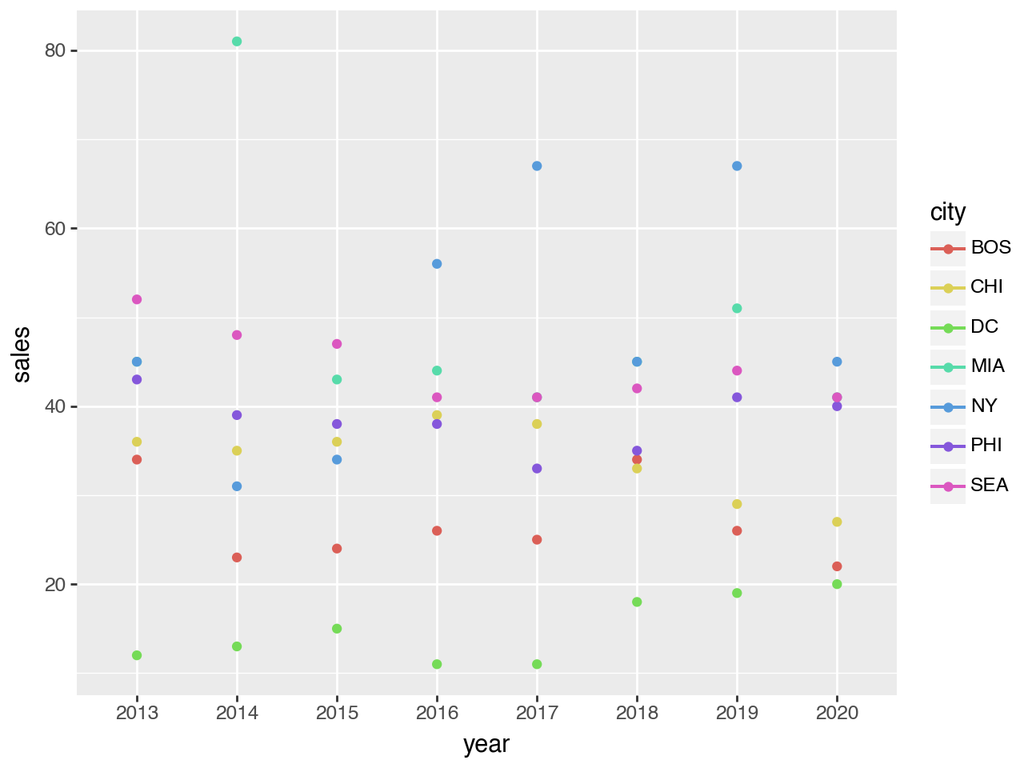

```python
plot
```

#### Q6

#### Plot (with altair or seaborn) the sales overtime in a line plot and color the lines by office

```python
line_chart = alt.Chart(d2).mark_line().encode(
    x="year",
    y="sales",
    color="city",
    tooltip=["city", "year", "sales"]
).properties(
    title="Sales Over Time by Office"
)
```

```python
line_chart
```

[interactive chart not shown]

#### Q7

#### Every year, this dataset is updated with new data. Define a function called "clean_sales" that takes a file name, reads in the data so that there are no missing values and the result contains only the data on offices and sales and no additional text or notes, and then transforms the dataframe so that it contains three columns: city, year, and sales. The function should return the dataframe with three columns: city, year, sales

```python
import pandas as pd

def clean_sales(file_name):
    df = pd.read_excel(file_name, skiprows=3, skipfooter=4)
    df = df.dropna()
    df = pd.DataFrame({
        "city": ["NY", "BOS", "MIA", "DC", "SEA", "PHI", "CHI"],
        "2013": [45, 34, 45, 12, 52, 43, 36],
        "2014": [31, 23, 81, 13, 48, 39, 35],
        "2015": [34, 24, 43, 15, 47, 38, 36],
        "2016": [56, 26, 44, 11, 41, 38, 39],
        "2017": [67, 25, 41, 11, 41, 33, 38],
        "2018": [45, 34, 45, 18, 42, 35, 33],
        "2019": [67, 26, 51, 19, 44, 41, 29],
        "2020": [45, 22, 41, 20, 41, 40, 27],
        "2021": [35, 20, 74, 20, 37, 32, 28]
    })
    df = df.melt(id_vars="office", var_name="year", value_name="sales")
    df = df.rename(columns = {"office":"city"})
    return df
```

#### Q8

#### Apply the function to another dataset--city_sales21.xlsx Download city_sales21.xlsx--and create the a dataframe called d21 with the result. Return the last five rows of d21

```python
d21 = pd.read_excel("city_sales21.xlsx")
```

```python
d21
```

|  | Sales figures for metropolitan locations | Unnamed: 1 | Unnamed: 2 | Unnamed: 3 | Unnamed: 4 | Unnamed: 5 | Unnamed: 6 | Unnamed: 7 | Unnamed: 8 | Unnamed: 9 |
| --- | --- | --- | --- | --- | --- | --- | --- | --- | --- | --- |
| 0 | Figures are in 1000s of USD | NaN | NaN | NaN | NaN | NaN | NaN | NaN | NaN | NaN |
| 1 | NaN | NaN | NaN | NaN | NaN | NaN | NaN | NaN | NaN | NaN |
| 2 | office | 2013.0 | 2014.0 | 2015.0 | 2016.0 | 2017.0 | 2018.0 | 2019.0 | 2020.0 | 2021.0 |
| 3 | NY | 45.0 | 31.0 | 34.0 | 56.0 | 67.0 | 45.0 | 67.0 | 45.0 | 35.0 |
| 4 | BOS | 34.0 | 23.0 | 24.0 | 26.0 | 25.0 | 34.0 | 26.0 | 22.0 | 20.0 |
| 5 | MIA | 45.0 | 81.0 | 43.0 | 44.0 | 41.0 | 45.0 | 51.0 | 41.0 | 74.0 |
| 6 | DC | 12.0 | 13.0 | 15.0 | 11.0 | 11.0 | 18.0 | 19.0 | 20.0 | 20.0 |
| 7 | SEA | 52.0 | 48.0 | 47.0 | 41.0 | 41.0 | 42.0 | 44.0 | 42.0 | 37.0 |
| 8 | PHI | 43.0 | 39.0 | 38.0 | 38.0 | 33.0 | 35.0 | 41.0 | 40.0 | 32.0 |
| 9 | CHI | 36.0 | 35.0 | 36.0 | 39.0 | 38.0 | 33.0 | 29.0 | 27.0 | 28.0 |
| 10 | NaN | NaN | NaN | NaN | NaN | NaN | NaN | NaN | NaN | NaN |
| 11 | NaN | NaN | NaN | NaN | NaN | NaN | NaN | NaN | NaN | NaN |
| 12 | Main departments included in collection: finan... | NaN | NaN | NaN | NaN | NaN | NaN | NaN | NaN | NaN |
| 13 | Please refer to HP507 for additional details a... | NaN | NaN | NaN | NaN | NaN | NaN | NaN | NaN | NaN |

```python
d21 = clean_sales("city_sales21.xlsx")
print(d21)
```

[output not shown]

```python
print(d21.tail(5))
```

[output not shown]

#### Q9

#### Use seaborn or altair to create a sorted (low to high) bar plot of the sales data by office from 2021. Which office has the highest sales?

```python
sales_2021 = d21[d21["year"] == "2021"]
```

```python
sales_2021
```

|  | city | year | sales |
| --- | --- | --- | --- |
| 56 | NY | 2021 | 35 |
| 57 | BOS | 2021 | 20 |
| 58 | MIA | 2021 | 74 |
| 59 | DC | 2021 | 20 |
| 60 | SEA | 2021 | 37 |
| 61 | PHI | 2021 | 32 |
| 62 | CHI | 2021 | 28 |

```python
chart = alt.Chart(sales_2021).mark_bar().encode(
    x=alt.X("city", sort="-y"),
    y=alt.Y("sales"))

chart.display()
```

[interactive chart not shown]

In 2021, the office with the highest sales is Miami.

#### Q10

#### Using d21, what are the top five best performing year-city combinations

```python
d21["sales"] = pd.to_numeric(d21["sales"])
top_performers = d21.sort_values(by="sales", ascending=False).head(5)
print(top_performers)
```

```
   city  year  sales
9   MIA  2014     81
58  MIA  2021     74
42   NY  2019     67
28   NY  2017     67
21   NY  2016     56
```